# Chapter 2

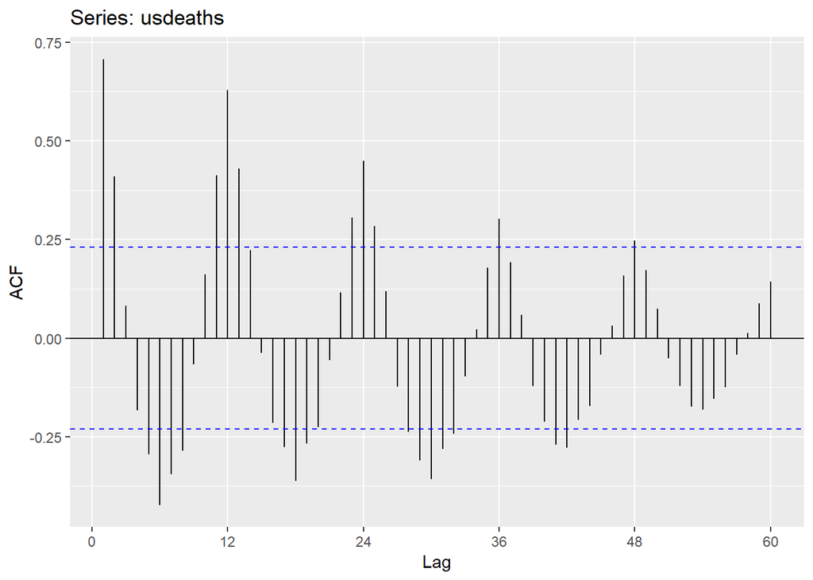

```r
ggAcf(usdeaths, lag.max = 60)
```

```r
# can spot seasonality
```

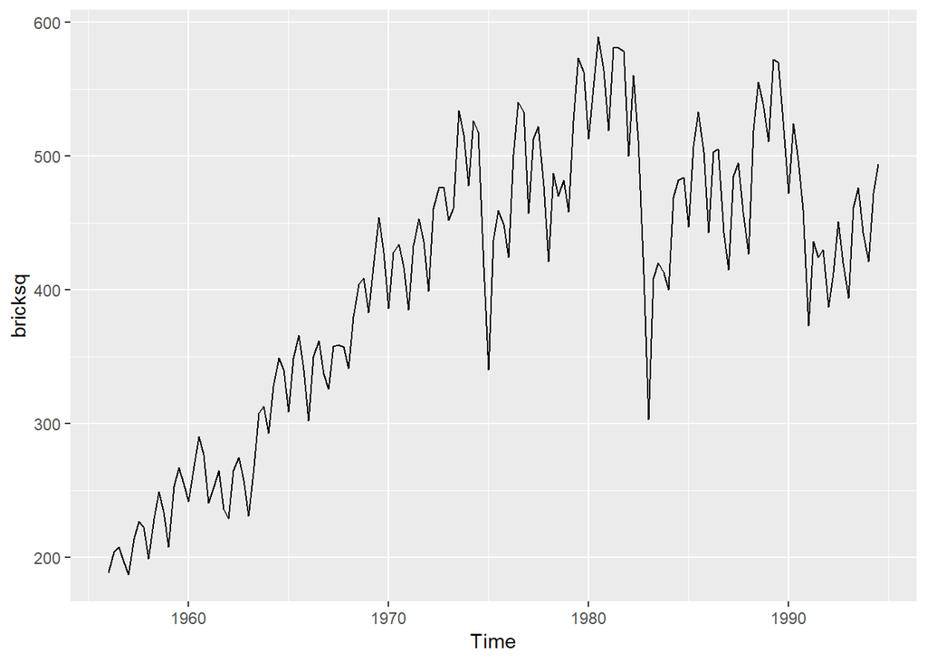

```r
autoplot(bricksq)
```

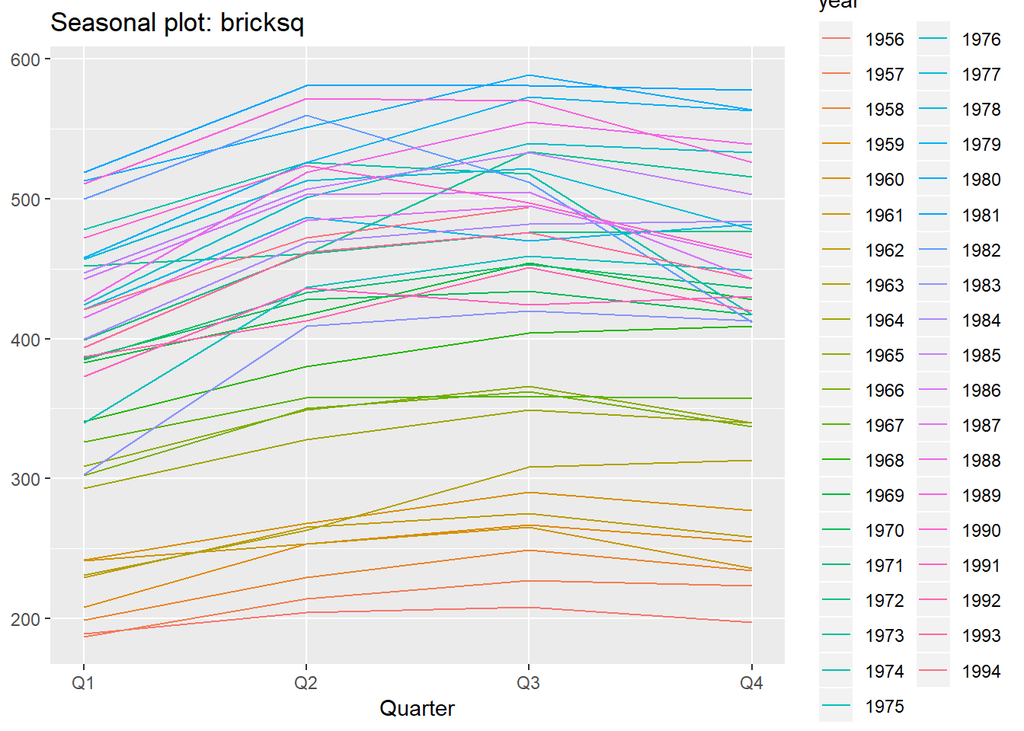

```r
ggseasonplot(bricksq)
```

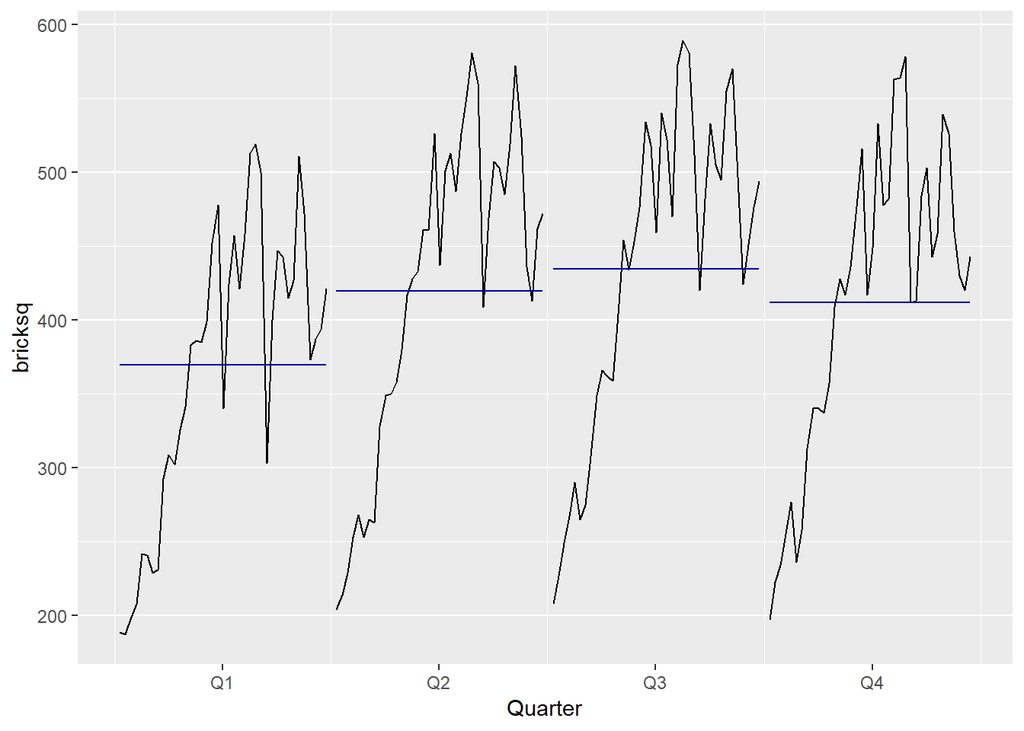

```r
ggsubseriesplot(bricksq)
```

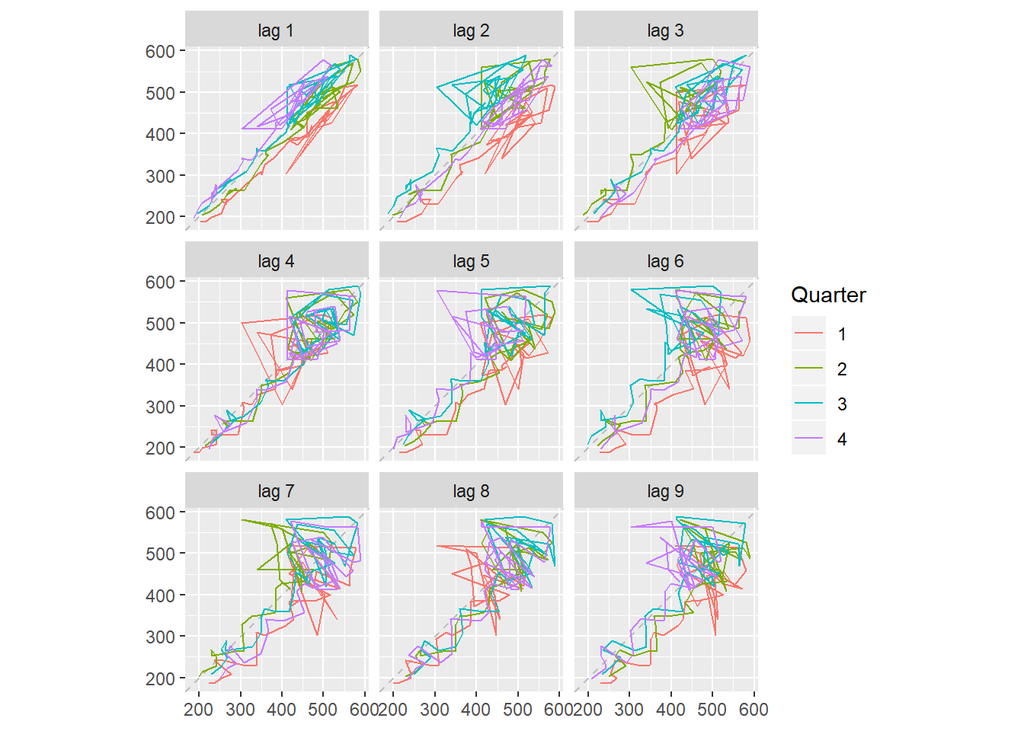

```r
gglagplot(bricksq)
```

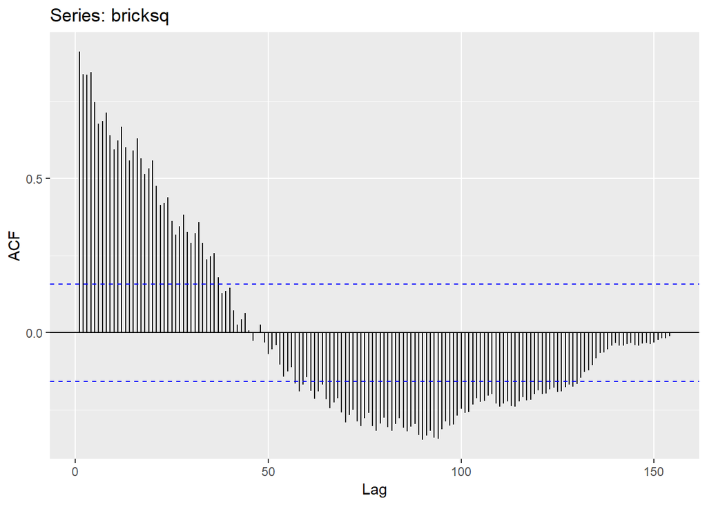

```r
ggAcf(bricksq, lag.max = 200)
```

```r
# can spot little seasonality and strong trend
```

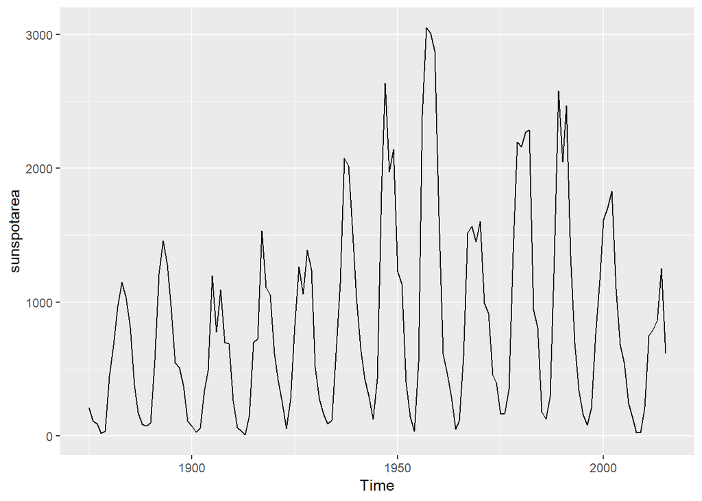

```r
autoplot(sunspotarea)
```

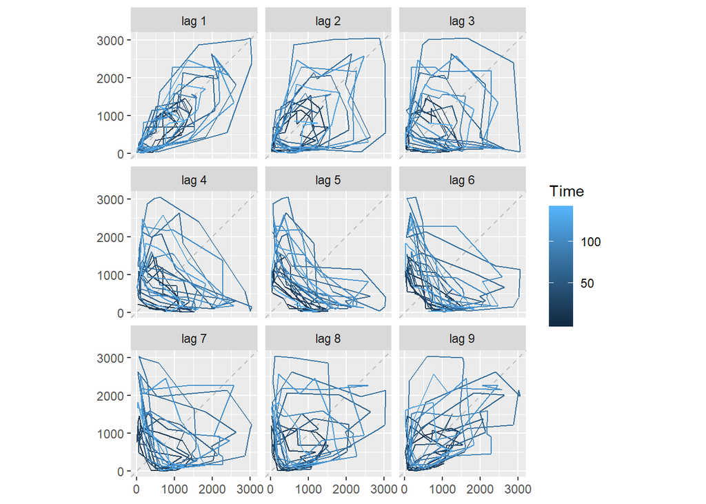

```r
# ggseasonplot(sunspotarea)
# not seasonal, can't draw it
# ggsubseriesplot(sunspotarea)
# not seasonal, useless to draw it
gglagplot(sunspotarea)
```

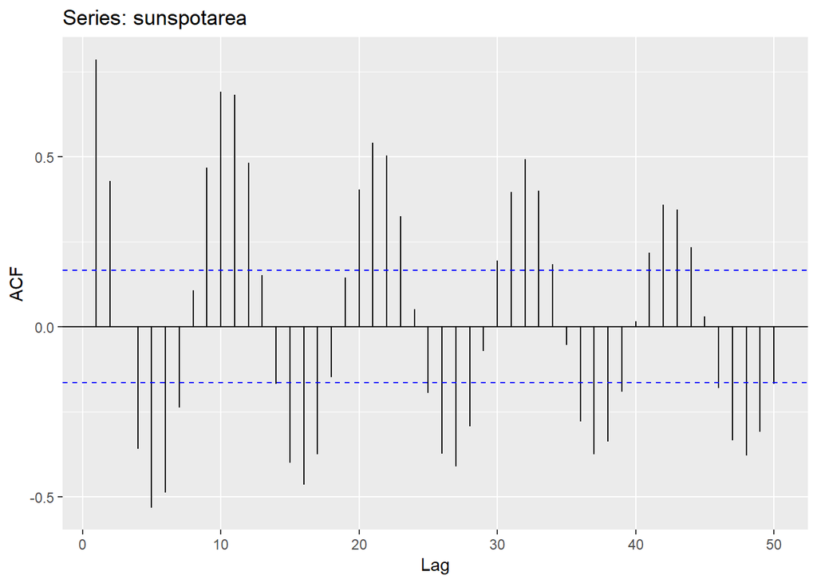

```r
ggAcf(sunspotarea, lag.max = 50)
```

```r
# can spot strong cyclicity
```

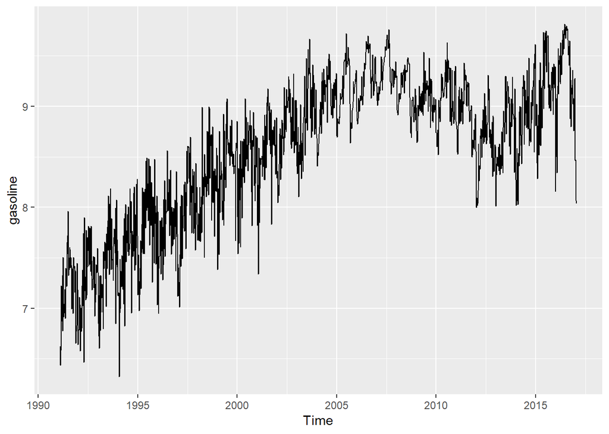

```r
autoplot(gasoline)
```

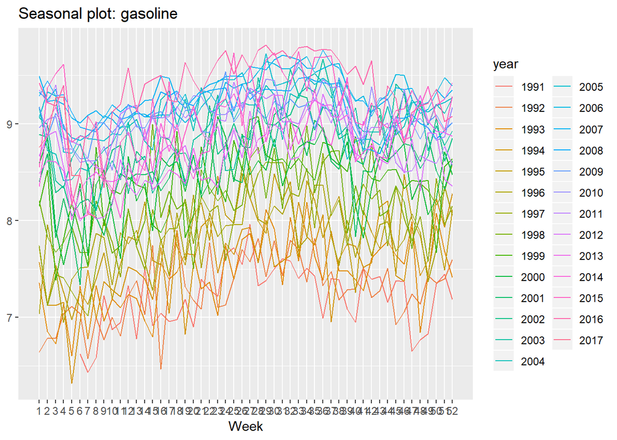

```r
ggseasonplot(gasoline)
```

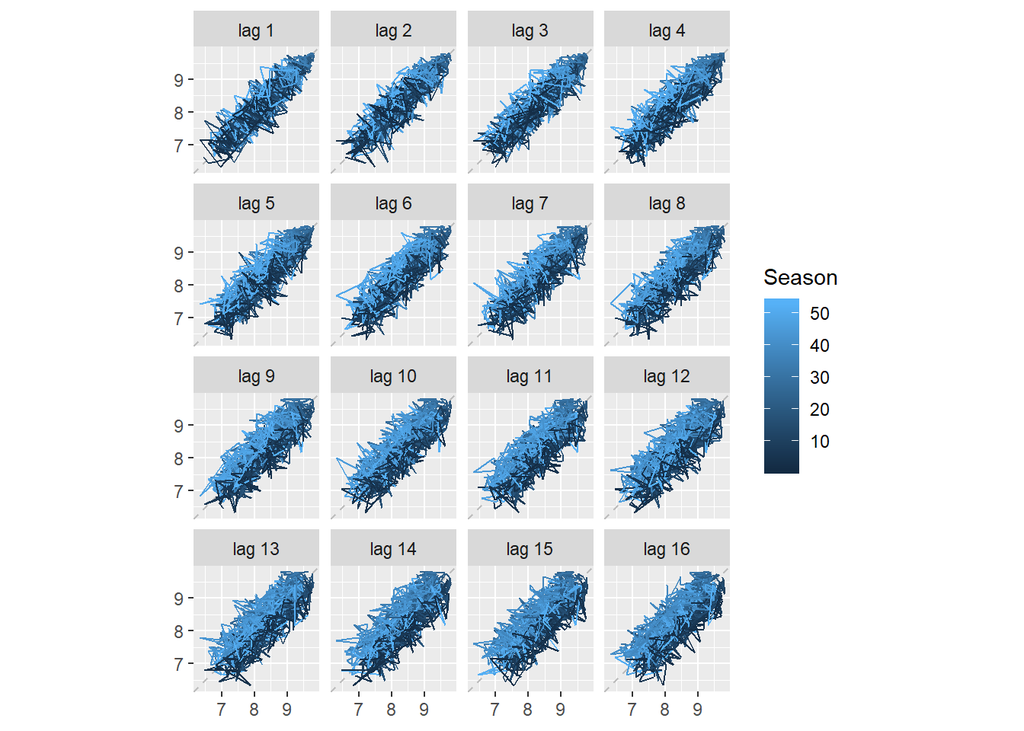

```r
# ggsubseriesplot(gasoline)
# The number of weeks is 52 and it looked like it is too much for subseriesplot
gglagplot(gasoline)
```

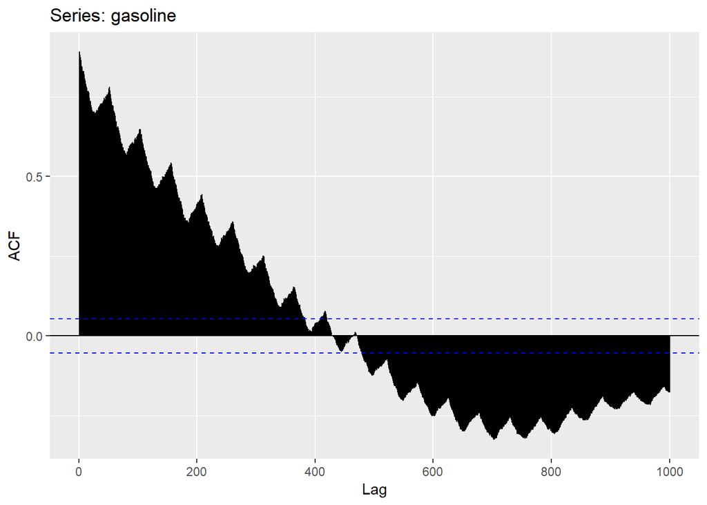

```r
ggAcf(gasoline, lag.max = 1000)
```

```r
# can spot seasonality and trend
```

7. The arrivals data set comprises quarterly international arrivals (in thousands) to Australia from Japan, New Zealand, UK and the US.

```r
# See the structure of arrivals
str(arrivals)
```

```
##  Time-Series [1:127, 1:4] from 1981 to 2012: 14.76 9.32 10.17 19.51 17.12 ...
##  - attr(*, "dimnames")=List of 2
##   ..$ : NULL
##   ..$ : chr [1:4] "Japan" "NZ" "UK" "US"
```

```r
# - Use autoplot, ggseasonplot and ggsubseriesplot to compare the differences between the arrivals from these four countries.
# - Can you identify any unusual observations?
```

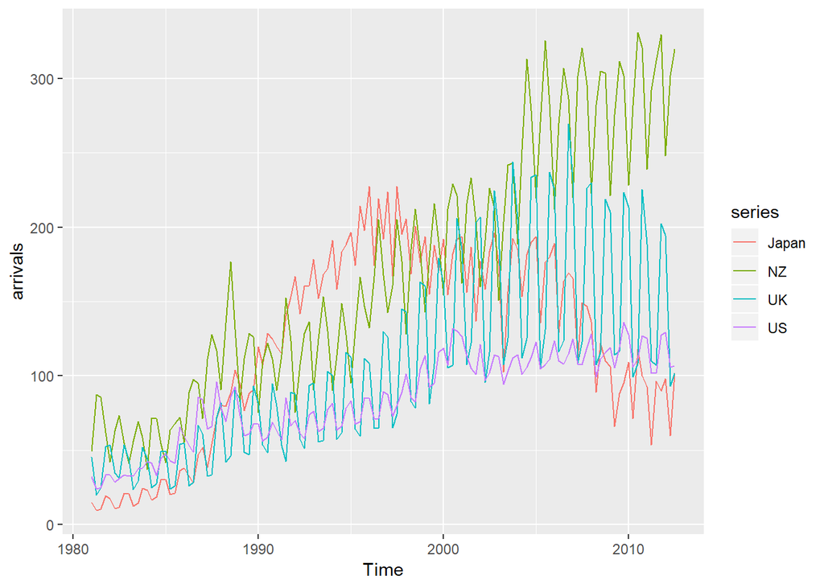

```r
autoplot(arrivals)
```

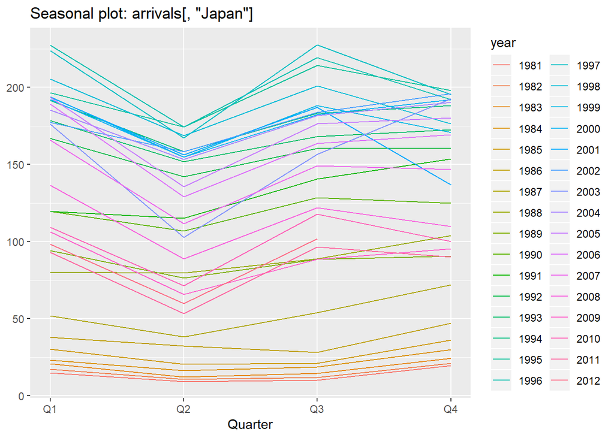

```r
ggseasonplot(arrivals[, "Japan"])
```

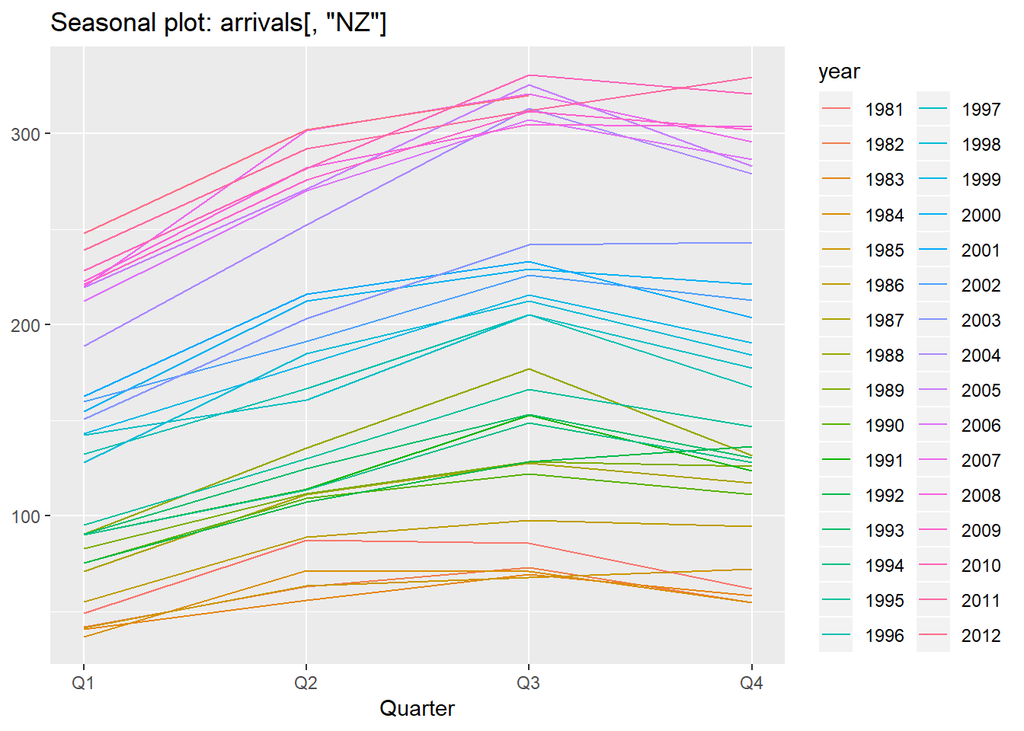

```r
ggseasonplot(arrivals[, "NZ"])
```

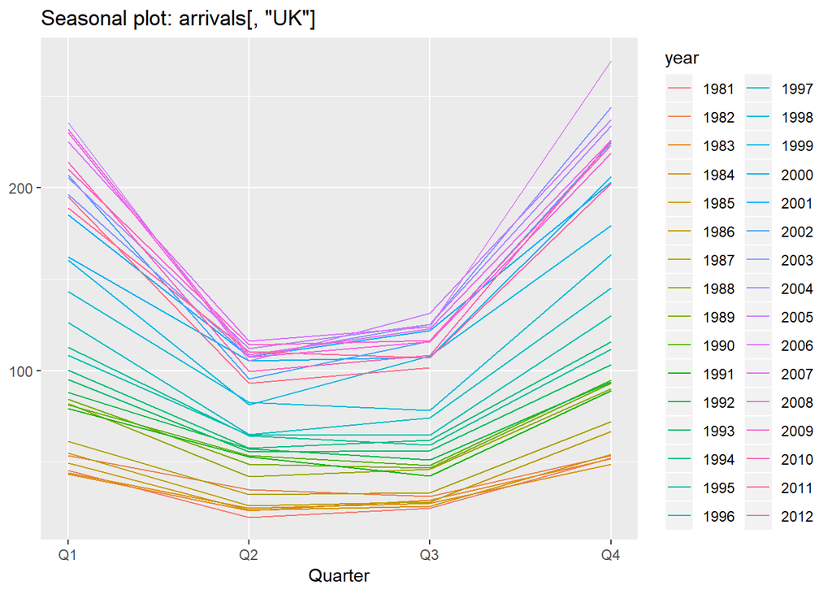

```r
ggseasonplot(arrivals[, "UK"])
```

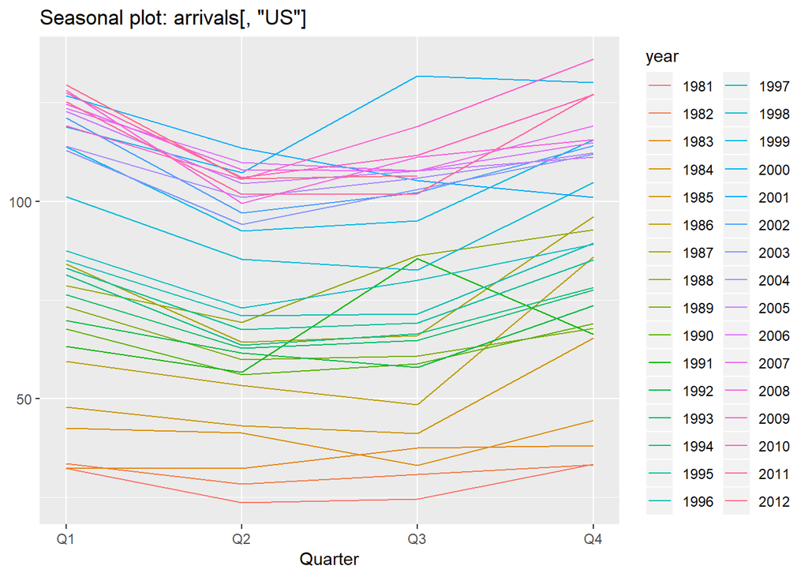

```r
ggseasonplot(arrivals[, "US"])
```

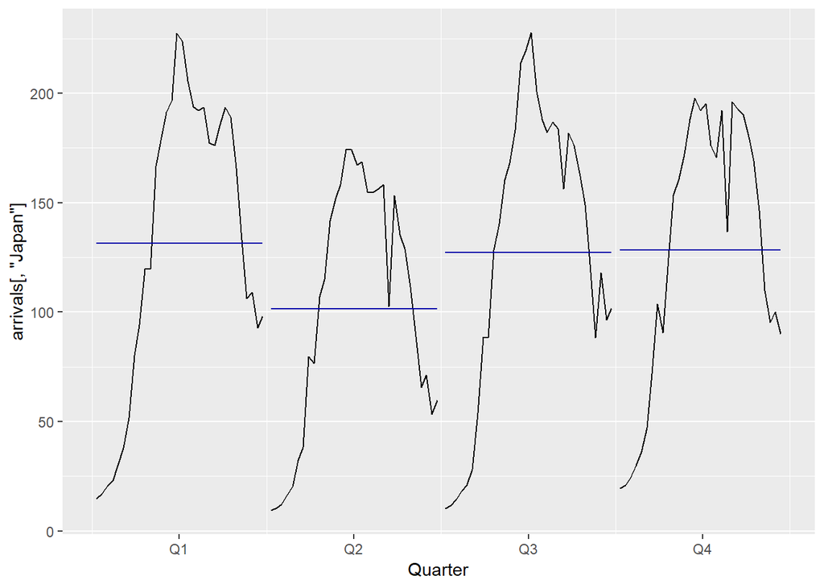

```r
ggsubseriesplot(arrivals[, "Japan"])
```

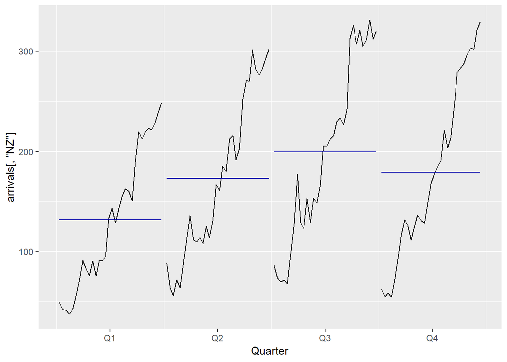

```r
ggsubseriesplot(arrivals[, "NZ"])
```

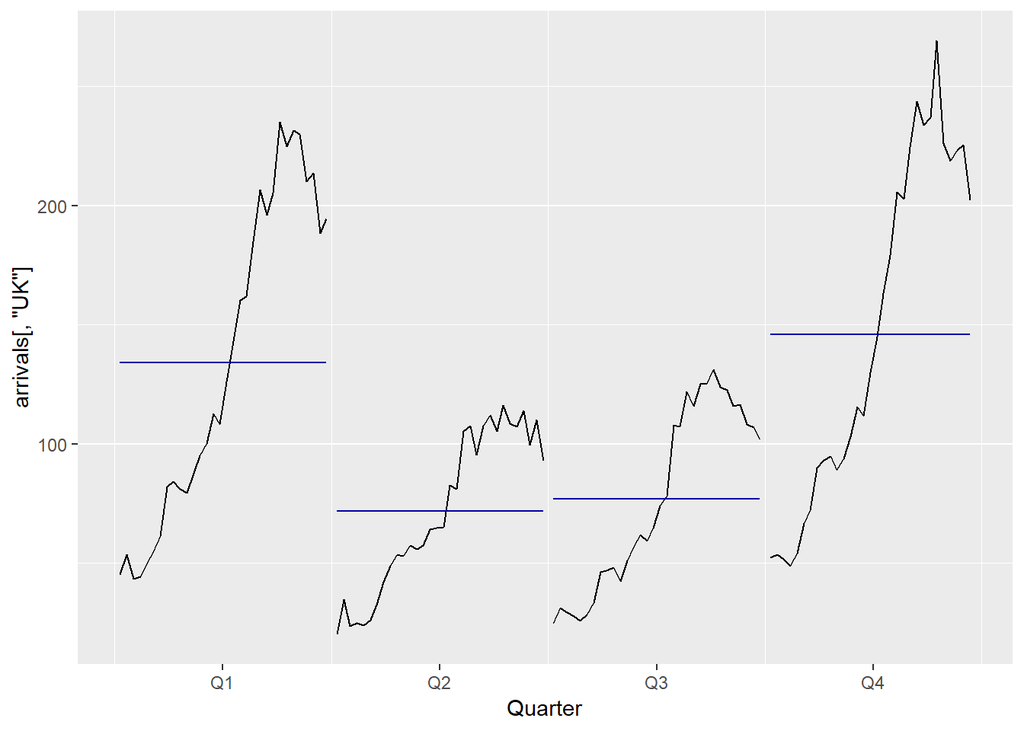

```r
ggsubseriesplot(arrivals[, "UK"])
```

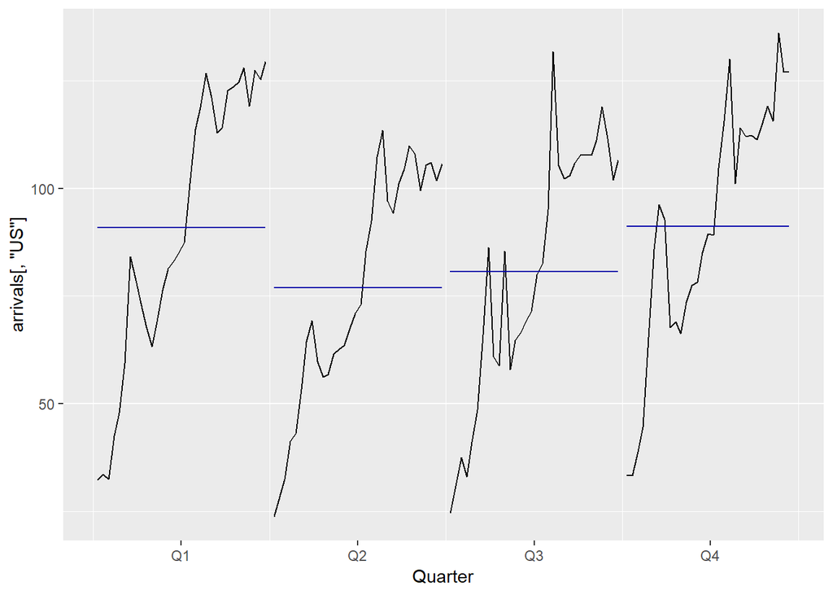

```r
ggsubseriesplot(arrivals[, "US"])
```

```r
# The arrivals from Japan decrease in the 2nd quarter.
# The arrivals from New Zealand are highest in the 3rd quarter and lowest in the 1st quarter.
# The arrivals from UK are fewer in the 2nd quarter and increasing in the third quarter.
# The arrivals from US are fewer in the 2nd quarter and like the ones from UK, they are increasing in the 3rd quarter.
```

9. The pigs data shows the monthly total number of pigs slaughtered in Victoria, Australia, from Jan 1980 to Aug 1995. Use mypigs <- window(pigs, start=1990) to select the data starting from 1990. Use autoplot and ggAcf for mypigs series and compare these to white noise plots from Figures 2.15 and 2.16. (Subchapter 9)

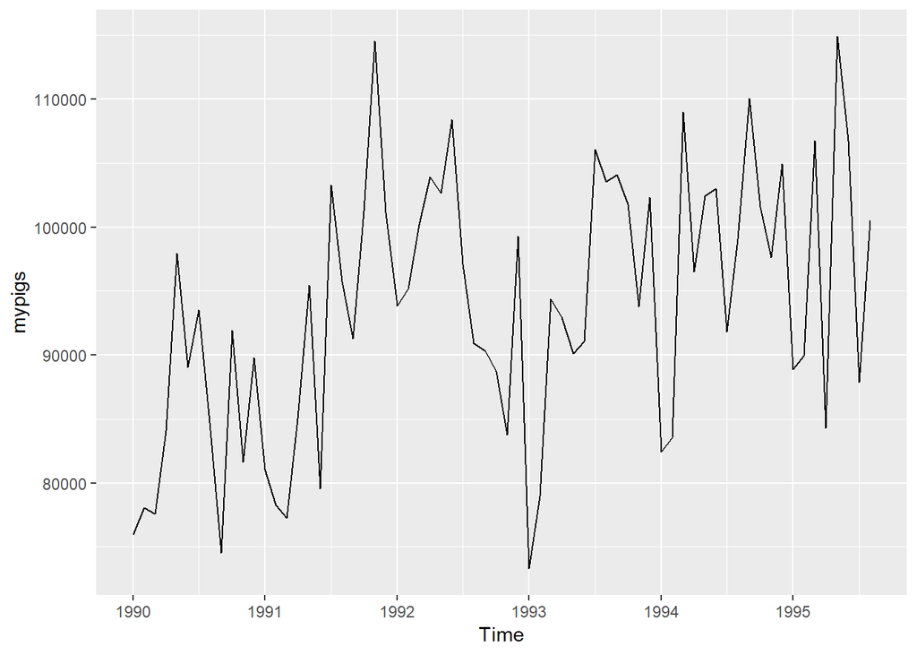

```r
mypigs <- window(pigs, start=1990)
#str(mypigs)
autoplot(mypigs)
```